# PF-0953 Programación geoespacial en R Tarea 02: R - Graficación

María Dilena Cruz Fernández

2020-09-16

## Descripción general

En esta tarea, aplicará varios comandos de graficación en el lenguaje [R](https://www.r-project.org/). Además, aprenderá a bifurcar y clonar repositorios basados en el sistema [Git](https://git-scm.com/) de control de versiones y hospedados en la plataforma [GitHub](https://github.com/), para editarlos en su estación de trabajo mediante [RStudio](https://rstudio.com/). El resultado final será un documento en la sintaxis [R Markdown](https://rmarkdown.rstudio.com/) publicado en [GitHub Pages](https://pages.github.com/).

## Fecha de entrega y entregables

La fecha límite de entrega de este laboratorio es el **23 de setiembre de 2020 a las 5:00 p.m.** Debe enviarle al profesor por correo electrónico la dirección del sitio en GitHub Pages resultante (ej. https://usuario.github.io/tarea-02-r-graficacion/).

## Objetivos

1. Aprender a bifurcar un repositorio en GitHub.
2. Aprender a clonar un repositorio mediante el protocolo Git y la interfaz de RStudio.
3. Aprender a editar un documento en R Markdown, incluyendo código en el lenguaje R.
4. Aplicar comandos de graficación de R.

## Trabajo previo

Se recomienda leer el material preparado por el profesor y consultar los recursos listados en [Lección 04: El lenguaje de programación R - Graficación](https://pf0953-programaciongeoespacialr-2020.github.io/leccion-04-r-graficacion/).

Además de R y RStudio, debe instalar el sistema para control de versiones [Git](https://git-scm.com/downloads).

## Bifuración y clonación de este documento

Ejecute los siguientes pasos para bifurcar a su cuenta en GitHub el repositorio que contiene este documento y posteriormente clonarlo a su computadora para editarlo con RStudio:

1. Bifurque (*fork*) el repositorio https://github.com/pf0953-programaciongeoespacialr-2020/tarea-02-r-graficacion a su cuenta personal en GitHub.
2. En el apartado *Settings* del repositorio bifurcado a su cuenta, busque la sección *GitHub Pages* y habilítela al seleccionar *master branch* como fuente. Tome nota de la dirección web resultante (ej. https://usuario.github.io/tarea-02-r-graficacion/).
3. En RStudio, clone el repositorio de su cuenta personal con la opción de menú *File - New Project - Version Control - Git*. En *Repository URL* escriba la dirección de su repositorio (ej. https://github.com/usuario/tarea-02-r-graficacion.git). Puede obtener esta dirección con el botón *Clone or download*, en la página principal del mismo repositorio.
4. Abra y modifique el documento en RStudio (para probar, puede incluir su nombre como autor del documento).
5. Cada vez que desee actualizar su documento en GitHub y GitHub Pages:
- Presione el botón *Knit* en RStudio para generar el documento correspondiente en la sintaxis HTML.
- Suba a su repositorio en GitHub, los archivos *index.Rmd* e *index.html*.

## Desarrollo

Realice los siguientes ejercicios de graficación en R (el valor porcentual de cada uno se muestra entre paréntesis).

1. (10%) Mediante la función `read.csv()`, cargue en un data frame el archivo CSV con datos de casos de Covid-19 ubicado en https://raw.githubusercontent.com/pf0953-programaciongeoespacialr-2020/datos/master/covid19/casos/ca/2020_09_15_CSV_GENERAL.csv. Luego, despliéguelos en la pantalla.

```r
# Importación de datos de casos recuperados, fallecidos, activos y positivos de Covid-19 en los países de Centroamérica
ca_covid19 <- read.csv(file='https://raw.githubusercontent.com/pf0953-programaciongeoespacialr-2020/datos/master/covid19/casos/ca/2020_09_15_CSV_GENERAL.csv')

# Despliegue de los datos
View(ca_covid19)
```

2. (10%) Genere un resumen de los datos con la función `summary()`.

```r
summary (ca_covid19)
```

```
##      pais             fallecidos      recuperados       activos
##  Length:8           Min.   :  19.0   Min.   :  540   Min.   :  150
##  Class :character   1st Qu.: 510.8   1st Qu.:14761   1st Qu.: 5370
##  Mode  :character   Median :1395.0   Median :20493   Median :16068
##                     Mean   :1353.8   Mean   :36094   Mean   :18667
##                     3rd Qu.:2108.5   3rd Qu.:72683   3rd Qu.:27929
##                     Max.   :2984.0   Max.   :78387   Max.   :48046
##    positivos
##  Min.   :  1501
##  1st Qu.: 21285
##  Median : 63379
##  Mean   : 56137
##  3rd Qu.: 87699
##  Max.   :104803
```

3. Genere gráficos de barras de los casos positivos (20%), recuperados (20%), activos (20%) y fallecidos (20%).

Las barras deben estar ordenadas de mayor (a la izquierda o arriba) a menor (a la derecha o abajo) cantidad de casos. Incluya en el gráfico los siguientes componentes:

- Titulo del gráfico.
- Etiquetas en ambos ejes (x, y).
- Nombres de los países en el eje correspondiente.
- Cantidad de casos en cada barra.

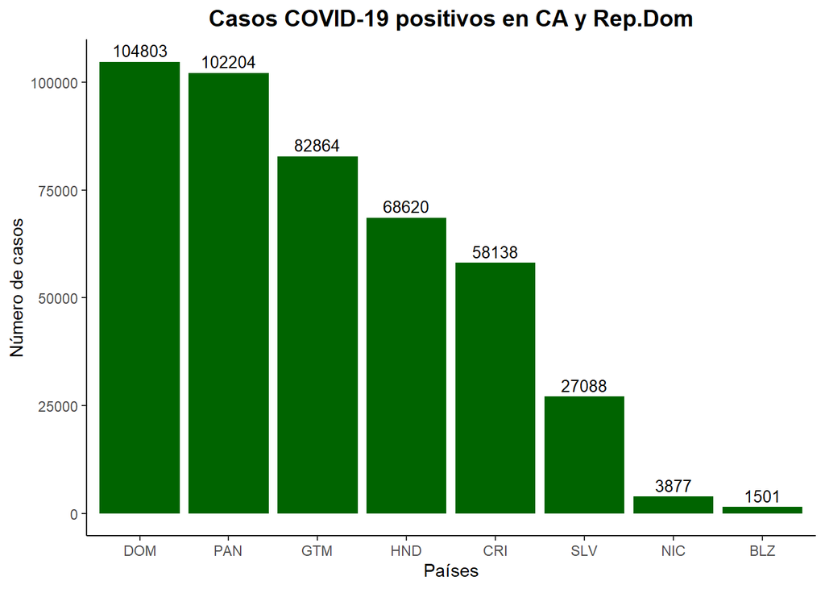

```r
library(ggplot2)

ggplot(ca_covid19, aes(x=reorder(pais, -positivos), y=positivos))+
geom_col(fill="dark green")+
  ggtitle("Casos COVID-19 positivos en CA y Rep.Dom")+
  xlab("Países")+
  ylab("Número de casos")+
  theme_classic()+
  geom_text(aes(label=positivos), vjust=-0.4, size=3.5)+
  theme(plot.title = element_text(hjust = 0.5, size = 14, face = "bold"))
```

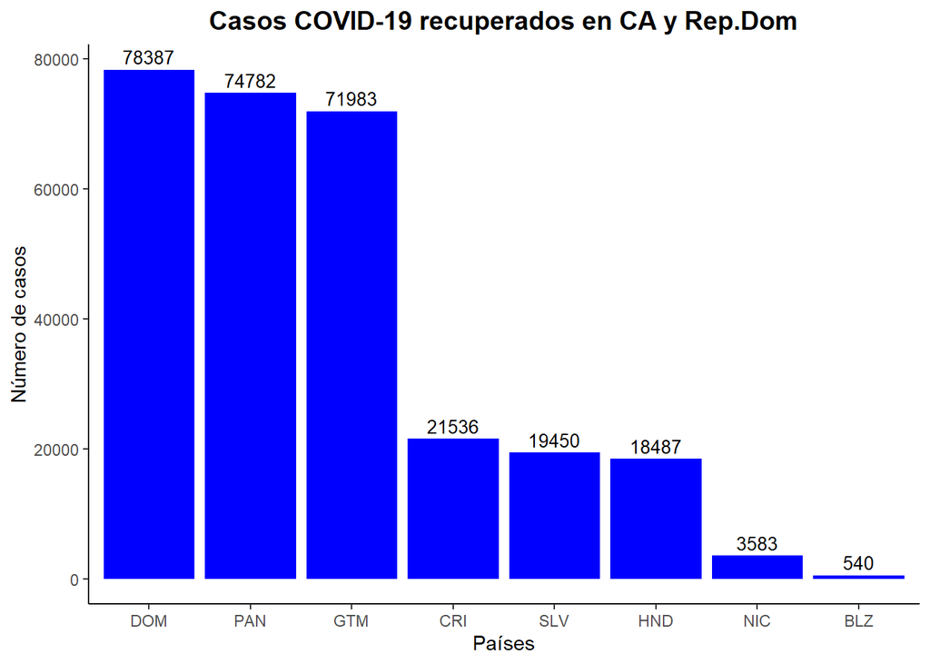

```r
ggplot(ca_covid19, aes(x=reorder(pais, -recuperados), y=recuperados))+
geom_col(fill="blue")+
  ggtitle("Casos COVID-19 recuperados en CA y Rep.Dom")+
  xlab("Países")+
  ylab("Número de casos")+
  theme_classic()+
  geom_text(aes(label=recuperados), vjust=-0.4, size=3.5)+
  theme(plot.title = element_text(hjust = 0.5, size = 14, face = "bold"))
```

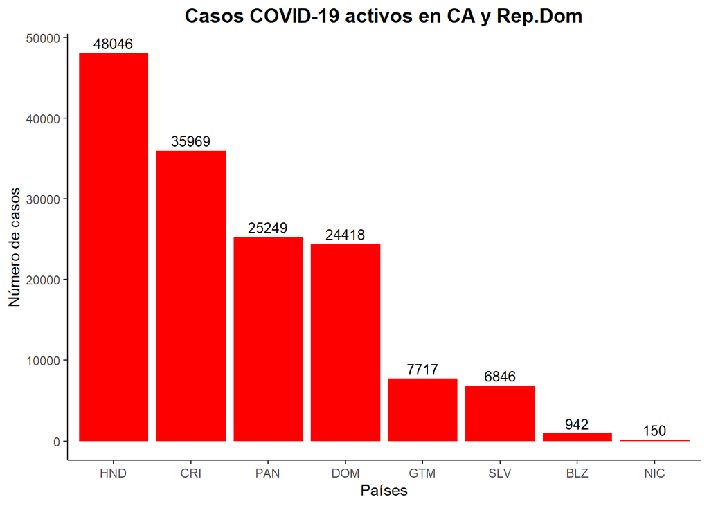

```r
ggplot(ca_covid19, aes(x=reorder(pais, -activos), y=activos))+
geom_col(fill="red")+
  ggtitle("Casos COVID-19 activos en CA y Rep.Dom")+
  xlab("Países")+
  ylab("Número de casos")+
  theme_classic()+
  geom_text(aes(label=activos), vjust=-0.4, size=3.5)+
  theme(plot.title = element_text(hjust = 0.5, size = 14, face = "bold"))
```

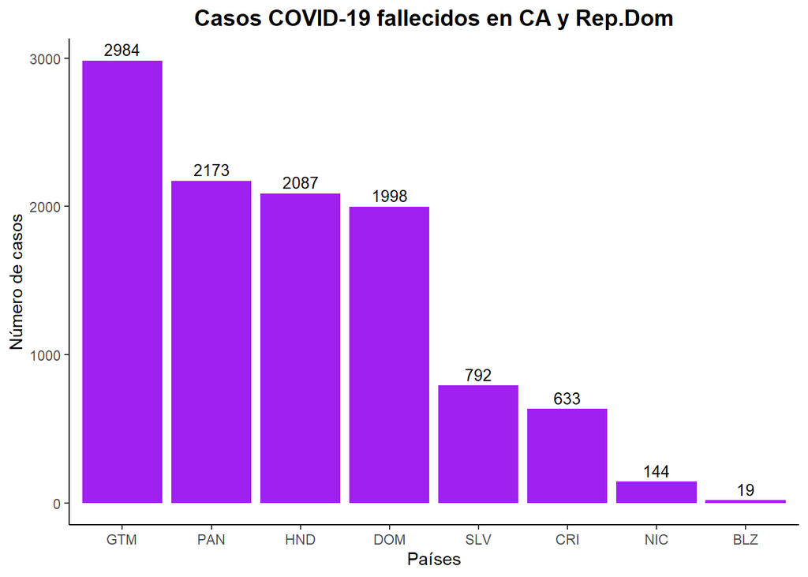

```r
ggplot(ca_covid19, aes(x=reorder(pais, -fallecidos), y=fallecidos))+
geom_col(fill="purple")+
  ggtitle("Casos COVID-19 fallecidos en CA y Rep.Dom")+
  xlab("Países")+
  ylab("Número de casos")+
  theme_classic()+
  geom_text(aes(label=fallecidos), vjust=-0.4, size=3.5)+
  theme(plot.title = element_text(hjust = 0.5, size = 14, face = "bold"))
```

4. (10% - OPCIONAL) Genere un solo gráfico de barras que presente los cuatros tipos de casos, ya sea en barras apiladas o agrupadas.

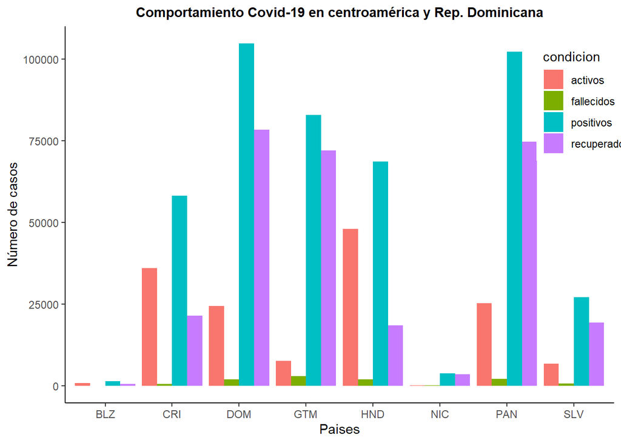

```r
library(tidyr)
acomodo<- gather(ca_covid19, condicion, cantidad, -pais)

ggplot(acomodo, aes(x = pais, y = cantidad, fill = condicion)) +
  geom_col(position = "dodge")+
  ggtitle("Comportamiento Covid-19 en centroamérica y Rep. Dominicana")+ xlab("Paises")+ ylab("Número de casos")+
  theme_classic() + theme(plot.title = element_text(hjust = 0.5, size = 11, face = "bold"), legend.position = c(0.95, 0.8))
```